# DSS Comptuing Bootcamp

Aug 24, 2017

## Before we start

A couple things to get everyone on the same page,

- If you don't have one, sign up for a GitHub account (it takes 1 min.)
  - Go to https://github.com/join
  - Enter your information
  - Pick the `Unlimited public repositories for free.` plan
- Try logging into (one of) the department's RStudio servers
  - Master's students: http://saxon.stat.duke.edu:8787
  - PhD students: http://smith.stat.duke.edu:8787
  - Login and password are your `netid` and associated password.

## Materials

- Slides and all source code at https://github.com/DukeStatSci/ComputingBootcamp2017
- *Very* useful resources from RStudio: https://www.rstudio.com/resources/cheatsheets/
  - [R Markdown cheat sheet](https://www.rstudio.com/wp-content/uploads/2016/03/rmarkdown-cheatsheet-2.0.pdf)
  - [R Markdown reference guide](https://www.rstudio.com/wp-content/uploads/2015/03/rmarkdown-reference.pdf)
  - [Data transformation with dplyr sheet](https://github.com/rstudio/cheatsheets/raw/master/source/pdfs/data-transformation-cheatsheet.pdf)
  - [Data visualization with ggplot2 cheat sheet](https://www.rstudio.com/wp-content/uploads/2016/11/ggplot2-cheatsheet-2.1.pdf)

## Reproducibility: who cares?

## Science retracts gay marriage paper without agreement of lead author LaCour

- In May 2015 Science retracted a study of how canvassers can sway people's opinions about gay marriage published just 5 months ago.
- Science Editor-in-Chief Marcia McNutt: Original survey data not made available for independent reproduction of results. + Survey incentives misrepresented. + Sponsorship statement false.
- Two Berkeley grad students who attempted to replicate the study quickly discovered that the data must have been faked.
- Methods we'll discuss today can't prevent this, but they can make it easier to discover issues.

Source: http://news.sciencemag.org/policy/2015/05/science-retracts-gay-marriage-paper-without-lead-author-s-consent

## Seizure study retracted after authors realize data got "terribly mixed"

From the authors of **Low Dose Lidocaine for Refractory Seizures in Preterm Neonates**:

*"The article has been retracted at the request of the authors. After carefully re-examining the data presented in the article, they identified that data of two different hospitals got terribly mixed. The published results cannot be reproduced in accordance with scientific and clinical correctness."*

Source: http://retractionwatch.com/2013/02/01/seizure-study-retracted-after-authors-realize-data-got-terribly-mixed/

## Bad spreadsheet merge kills depression paper, quick fix resurrects it

- The authors informed the journal that the merge of lab results and other survey data used in the paper resulted in an error regarding the identification codes. Results of the analyses were based on the data set in which this error occurred. Further analyses established the results reported in this manuscript and interpretation of the data are not correct.
- **Original conclusion:** Lower levels of CSF IL-6 were associated with current depression and with future depression […].
- **Revised conclusion:** Higher levels of CSF IL-6 and IL-8 were associated with current depression […].

Source: http://retractionwatch.com/2014/07/01/bad-spreadsheet-merge-kills-depression-paper-quick-fix-resurrects-it/

## Reproducibility: why should we care?

## Two-pronged approach

#1 Convince researchers to adopt a reproducible research workflow

#2 Train new researchers who don’t have any other workflow

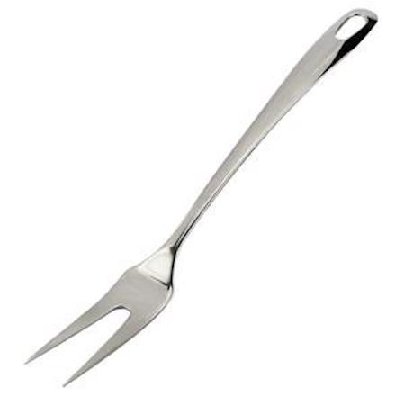

## Reproducible data analysis

- Scriptability \(\rightarrow\) R
- Literate programming \(\rightarrow\) R Markdown
- Version control \(\rightarrow\) git / GitHub

## Scripting and literate programming

## Donald Knuth "Literate Programming (1983)"

"Let us change our traditional attitude to the construction of programs: Instead of imagining that our main task is to instruct a *computer* what to do, let us concentrate rather on explaining to *human beings* what we want a computer to do."

"The practitioner of literate programming […] strives for a program that is comprehensible because its concepts have been introduced in an order that is best for human understanding, using a mixture of formal and informal methods that reinforce each other."

- These ideas have been around for years!
- and tools for putting them to practice have also been around
- but they have never been as accessible as the current tools

## Reproducibility checklist

- Are the tables and figures reproducible from the code and data?
- Does the code actually do what you think it does?
- In addition to what was done, is it clear *why* it was done? (e.g., how were parameter settings chosen?)
- Can the code be used for other data?
- Can you extend the code to do other things?

## Ambitious goal + many other concerns

We need an environment where

- data, analysis, and results are tightly connected, or better yet, inseparable
- reproducibility is built in
  - the original data remains untouched
  - all data manipulations and analyses are inherently documented
- documentation is human readable and syntax is minimal

## Toolkit

[figure not shown]

## What is markdown?

- Markdown is a lightweight markup language for creating HTML (or XHTML) documents.
- Markup languages are designed to produce documents from human readable text (and annotations).
- Some of you may be familiar with LaTeX. This is another (less human friendly) markup language for creating pdf documents.
- Why I love Markdown:
  - Easy to learn and use.
  - Focus on **content**, rather than **coding** and debugging **errors**.
  - Once you have the basics down, you can get fancy and add HTML, JavaScript, and CSS.

## Why should I use Markdown?

If you have an annoying process for authoring for the web …

or

If you avoid authoring for the web, because you're not sure how …

**start writing in Markdown**!

## Using RStudio

## Accessing RStudio

- Go to
  - PhD: http://smith.stat.duke.edu:8787/
  - MS: http://saxon.stat.duke.edu:8787/
  - UG: http://gort.stat.duke.edu:8787/
- Log in with your `netid` and password

## A brief foray into GitHub

[video not shown]

## R packages

- Packages are the fundamental units of reproducible R code. They include reusable R functions, the documentation that describes how to use them, and sample data.
- In the following exercises we'll use the `dplyr` and `ggplot2` packages.
- Install these packages by running the following in the *Console*

```r
install.packages("dplyr")
install.packages("ggplot2")
```

- Note that you will also need to load them in your markdown file (R code goes in chunks)

```r
library(dplyr)
library(ggplot2)
```

## It's your lucky day, you got some data!

Load the data using the `read.csv` function

```r
gap <- read.csv("https://bit.ly/gap_data")
```

## Tidy data

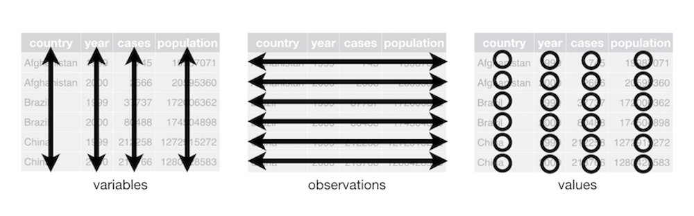

Source: Grolemund and Wickham, R for Data Science, http://r4ds.had.co.nz/

## Exercise 1

**How many observations are in this dataset?**

```r
nrow(gap)
```

```
## [1] 1363
```

## Exercise 2

**Visualize the relationship between GDP and life expectancy for countries in Europe in 1952 using a scatter plot.**

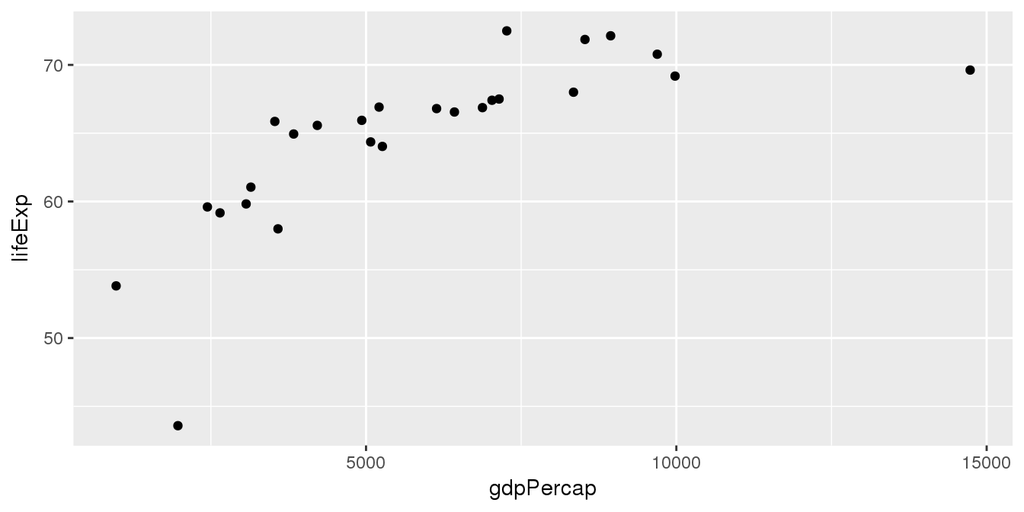

```r
eu_52 <- gap %>%
  filter(continent == "Europe", year == 1952)
ggplot(data = eu_52, aes(x = gdpPercap, y = lifeExp)) +
  geom_point()
```

## Exercise 3

**Ex 2: Add year 1967 in another color.**

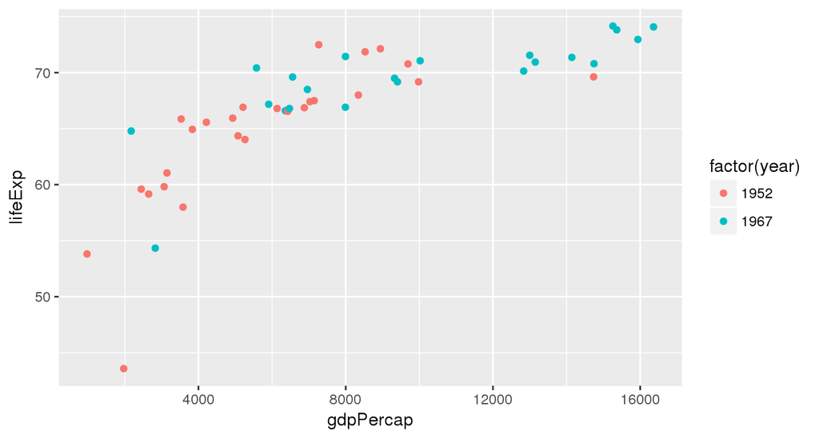

```r
eu_5267 <- gap %>%
  filter(continent == "Europe", year %in% c(1952, 1967))
ggplot(data = eu_5267, aes(x = gdpPercap, y = lifeExp, color = factor(year))) +
  geom_point()
```

## REDO!

**Ex REDO: Your collaborator realized that the data set they sent you was wrong. Repeat Exercises 1 and 2 with the updated dataset.**

```r
gap_upd <- read.csv("https://bit.ly/gap_data_upd")
```

## Formatting your document

Help -> Markdown Quick Reference

## Workflow

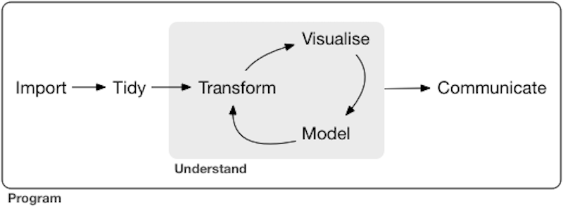

Source: Grolemund and Wickham, R for Data Science, http://r4ds.had.co.nz/

## Organizing a more complex analysis

- Use folders: raw_data, processed_data, code, figures, etc.
- Number your script files:
  - `00_load_data.R`
  - `01_data_cleanup.R`
  - `02_eda.R`
  - …
- Use informative names that indicate versioning
  - use dates
  - avoid things like `project_fin`, `project_finalfinal`, etc.

## On to ssh

## Remote connections

- You will be doing much of your work on remote linux systems, primarily you will be interacting with these machines through a remote terminal and a shell. Using a shell gives you more power to do more tasks more efficiently with your computer.
- OSX / Unix / Linux - these tools should already be installed and you should be able to access your shell through the Terminal application (name may vary slightly depending on your OS).
- Windows - there are several ways to install bash or a bash-like shell, the preferred method is to install the `git for windows` package: https://git-for-windows.github.io/.

## Secure shell (ssh)

- A secure tool for connecting and interacting with remote systems
- Uses public key encryption
- Run a single command or work interactively
- Lots of other neat tricks (proxying, port forwarding, etc.)

## Connecting to saxon / smith

- PhD: `smith`, MS: `saxon`
- Everyone should have a visitor account of the stats servers now
- Try to connect to make sure everything is working…

```bash
$ ssh cr173@saxon.stat.duke.edu
The authenticity of host 'saxon.stat.duke.edu (152.3.7.55)' can't be established
.
RSA key fingerprint is 74:30:5a:d0:cd:a8:d2:6f:a6:e9:c6:80:bb:eb:b4:ba.
Are you sure you want to continue connecting (yes/no)?yes
cr173@saxon.stat.duke.edu's password:
[cr173@saxon ~]$
```

## Working remotely

You should now be able to run commands remotely on `saxon`. We can interactively run commands on the remote system. Try `lscpu` to see the cpu configuration on server.

```bash
[cr173@saxon ~]$ lscpu
Architecture:          x86_64
CPU op-mode(s):        32-bit, 64-bit
Byte Order:            Little Endian
CPU(s):                24
On-line CPU(s) list:   0-23
Thread(s) per core:    2
Core(s) per socket:    6
Socket(s):             2
NUMA node(s):          2
Vendor ID:             GenuineIntel
CPU family:            6
Model:                 62
Stepping:              4
CPU MHz:               1200.000
BogoMIPS:              4199.43
Virtualization:        VT-x
L1d cache:             32K
L1i cache:             32K
L2 cache:              256K
L3 cache:              15360K
NUMA node0 CPU(s):     0-5,12-17
NUMA node1 CPU(s):     6-11,18-23
```

## Finishing up

Once you are done on the server you can exit by:

- Running `exit`
- Ctrl-D
- Wait long enough (connection will time out)

## Version control

## Why version control?

[figure not shown]

PhD Comics

## Why version control?

- Simple formal system for tracking all changes to a project
- Time machine for your projects
  - Track blame and/or praise
  - Remove the fear of breaking things
- Learning curve is steep, but when you need it you *REALLY* need it

> Your closest collaborator is you six months ago, but you don’t reply to emails.

– Paul Wilson, UW-Madison

## Why git?

- Distributed
  - Work online or offline
  - Collaborate with large groups
- Popular and Successful
  - Active development
  - Shiny new tools and ecosystems
  - Fast
- Tracks any type of file
- Branching
  - Smarter merges

[figure not shown]

## Git live demo

## Git live demo

- Forking a repository on GitHub
- Create a local copy of a repository
- Working with a local and remote repository
- Best practices for version control

## Learn more

- Happy Git with R by Jenny Bryan: http://happygitwithr.com/
- Try Git: https://try.github.io

## Departmental computing resources

## Departmental computing resources

- Graduate student computers are shared departmental resources
  - You'll be assigned a desktop to which you have priority, but it may be used by others as well (and you can use others' later if needed – more on this later)
- Dedicated servers:
  - `gort`: Undergrad
  - `saxon`: MS
  - `smith`: PhD
- Home directories are all network shared and backed up
- DSS computing inventory: https://www2.stat.duke.edu/lib/computer_inventory.php

## Acknowledgements

## Acknowledgements

- Some of the materials are result of the NSF supported [Reproducible Science Curriculum Hackathon](https://github.com/Reproducible-Science-Curriculum/Reproducible-Science-Hackathon-Dec-08-2014) that was held December 8-11, 2014, at the National Evolutionary Synthesis Center ([NESCent](http://nescent.org/)) in Durham, NC.
- [GitHub's ssh help pages](https://help.github.com/categories/56/articles)
- [Software Carpentry Project](http://software-carpentry.org/)
- Karl Broman - [Wisc's Tools4RR](http://kbroman.org/Tools4RR/)
- Karl Broman - [Reproducible Research](https://www.biostat.wisc.edu/~kbroman/presentations/repro_research_withnotes.pdf)
- Grolemund and Wickham - [R for Data Science](http://r4ds.had.co.nz/)
- [An Introduction to Using HTCondor](http://research.cs.wisc.edu/htcondor/HTCondorWeek2014/presentations/MillerK_IntroTutorial.pdf)